# HW3 Peer Assessment

Sun Jul 7 17:12:09 2024 PDT

# Part 1: Logistic Regression

# Background

The objective is to predict whether a passenger survived the Titanic disaster

## Data Description

1. **Survival**: (1 if the passenger survived, 0 if they did not).
2. **Pclass**: Numeric (1,2,3).
3. **Sex**: Categorical (male, female)
4. **Age**: Numeric.
5. **SibSp**: Number of siblings/spouses aboard.
6. **Parch**: Number of parents/children aboard.
7. **Fare**：Numeric.

## Setup

You can import the data and set up the problem with the following R code:

```r
# Import the data
rawdata = read.csv("C:/Users/yoges/OneDrive/Documents/ISYE 6414/HW3/Titanic.csv")

# Remove columns that we do not want
rawdata$X <- NULL
rawdata$PassengerId <- NULL
rawdata$Name <- NULL
rawdata$Ticket <- NULL
rawdata$Cabin <- NULL

# Set variables as categorical
rawdata$Pclass<-as.factor(rawdata$Pclass)
rawdata$Sex<-as.factor(rawdata$Sex)
rawdata$SibSp<-as.factor(rawdata$SibSp)
rawdata$Parch<-as.factor(rawdata$Parch)

# Print head of rawdata
head(rawdata)
```

|  | Survived | Pclass | Sex | Age | SibSp | Parch | Fare |
| --- | --- | --- | --- | --- | --- | --- | --- |
| 1 | 0 | 3 | male | 22 | 1 | 0 | 7.2500 |
| 2 | 1 | 1 | female | 38 | 1 | 0 | 71.2833 |
| 3 | 1 | 3 | female | 26 | 0 | 0 | 7.9250 |
| 4 | 1 | 1 | female | 35 | 1 | 0 | 53.1000 |
| 5 | 0 | 3 | male | 35 | 0 | 0 | 8.0500 |
| 6 | 0 | 3 | male | NA | 0 | 0 | 8.4583 |

**Note:** For all of the following questions, treat variables **Age** and **Fare** as quantitative variables and **Pclass**, **Sex**, **SibSp**,and **Parch** as categorical variables. Categorical variables have already been converted to factors in the starter code.

# Question 1: Fitting the Model - 9 pts

Use *Survived* as the response variable to fit a logistic regression model using logit as the link function with *Pclass* as the predictor. Call it **model1**.

**(a) 3 pts - Print the model1 summary table. What are the model parameters and estimates?**

```r
# Fit log regression
model1 <- glm(Survived ~ Pclass, data=rawdata, family=binomial(link='logit'))
check_model_1 = "Check"
# Print summary of model1
summary(model1)
```

```
##
## Call:
## glm(formula = Survived ~ Pclass, family = binomial(link = "logit"),
##     data = rawdata)
##
## Coefficients:
##             Estimate Std. Error z value Pr(>|z|)
## (Intercept)   0.5432     0.1415   3.840 0.000123 ***
## Pclass2      -0.6520     0.2045  -3.189 0.001430 **
## Pclass3      -1.6390     0.1767  -9.276  < 2e-16 ***
## ---
## Signif. codes:  0 '***' 0.001 '**' 0.01 '*' 0.05 '.' 0.1 ' ' 1
##
## (Dispersion parameter for binomial family taken to be 1)
##
##     Null deviance: 1170.0  on 873  degrees of freedom
## Residual deviance: 1072.1  on 871  degrees of freedom
## AIC: 1078.1
##
## Number of Fisher Scoring iterations: 4
```

Model Parameters and Estimates:

Intercept: 0.5432 Pclass2: -0.6520 Pclass3: -1.6390

**(b) 6 pts - Calculate the odds ratio and interpret the estimated coefficient of *Pclass3* with respect to the log-odds of survival and the odds of survival.**

```r
# Calculate ratio
exp_coef <- exp(coef(model1))
exp_coef
```

```
## (Intercept)     Pclass2     Pclass3
##   1.7215190   0.5209976   0.1941713
```

```r
#compare to log-odds of survival
# Interpretation
odds_ratio_pclass3 <- exp_coef["Pclass3"]
odds_ratio_pclass3
```

```
##   Pclass3
## 0.1941713
```

Odds ratio: $\exp^{(-1.6390)}$ = 0.194

The coefficient for Pclass3 is -1.6390, indicating that the log-odds of survival for third-class passengers are 1.6390 units lower than for first-class passengers.

The odds ratio of 0.1941713 suggests that third-class passengers have about 19.4% of the odds of surviving compared to first-class passengers, indicating their significantly reduced chances of survival.

# Question 2: Statistical Inference - 7 pts

**(a) 3 pts - Using model1, provide a 95% confidence interval for the coefficient of *Pclass3*.**

```r
# 95% confidence interval Pclass3
confint(model1,"Pclass3",level=0.95)
```

```
##     2.5 %    97.5 %
## -1.989093 -1.295879
```

The 95% confidence interval for the coefficient of Pclass3 ranges from -1.989 to -1.295

**(b) 4 pts - According to the summary table of model1, is *Pclass3* statistically significant? Is the overall regression statistically significant at the 0.01 significance level?**

```r
# Check significance
summary(model1)$coefficients
```

```
##               Estimate Std. Error   z value     Pr(>|z|)
## (Intercept)  0.5432070  0.1414608  3.839982 1.230434e-04
## Pclass2     -0.6520099  0.2044864 -3.188524 1.430011e-03
## Pclass3     -1.6390143  0.1767017 -9.275599 1.766241e-20
```

```r
summary_anova_1_check = 0

#define anova
# Overall  significance
anova(model1, test="Chisq")
```

|  | Df | Deviance | Resid. Df | Resid. Dev | Pr(>Chi) |
| --- | --- | --- | --- | --- | --- |
| NULL | NA | NA | 873 | 1169.985 | NA |
| Pclass | 2 | 97.92441 | 871 | 1072.061 | 5.444836e-22 |

The p-value for Pclass3 is less than 2e-16, which is far less than 0.01, indicating that Pclass3 is statistically significant.

The p-value for the overall regression is also less than 0.01, indicating that the overall regression model is statistically significant.

# Question 3: Goodness of fit - 17 pts

**(a) 5 pts - Assess the goodness-of-fit of model1 using both deviance residuals and Pearson residuals. What do you conclude?**

```r
# Deviance residuals
deviance_residuals <- residuals(model1,type ="deviance")

deviance_check_1 = "Check"
#return summary
summary(deviance_residuals)
```

```
##     Min.  1st Qu.   Median     Mean  3rd Qu.     Max.
## -1.41505 -0.75945 -0.75945 -0.06553  0.95706  1.66385
```

```r
# Pearson residuals
pearson_residuals <- residuals(model1, type = "pearson")
#return summary
summary(pearson_residuals)
```

```
##    Min. 1st Qu.  Median    Mean 3rd Qu.    Max.
## -1.3121 -0.5782 -0.5782  0.0000  0.7622  1.7296
```

The values of the residuals are mostly concentrated around zero, despite some variation indicating potential issues with the fit of the model. The extremes of residuals may suggest the model does not capture all the variability in data.

**(b) 2 pts - Calculate the estimated dispersion parameter for this model. Is this an overdispersed model?**

```r
# Estimated dispersion
dispersion <- sum(pearson_residuals^2)/df.residual(model1)
#return
dispersion
```

```
## [1] 1.003444
```

The parameter is close to 1, which suggests the model is not overdispersed.

**(c) 2 pts - Using *Survived* as the response variable with *Pclass*, *Sex*, *SibSp*, and *Parch* as the predictors and logit as the link function, fit a logistic regression model and call it** model2**.**

```r
# Fit logistic regression
model2 <- glm(Survived ~ Pclass +Sex +SibSp +Parch,data=rawdata,family=binomial(link='logit'))

# summary model2
summary(model2)
```

```
##
## Call:
## glm(formula = Survived ~ Pclass + Sex + SibSp + Parch, family = binomial(link = "logit"),
##     data = rawdata)
##
## Coefficients:
##             Estimate Std. Error z value Pr(>|z|)
## (Intercept)  2.24220    0.24694   9.080  < 2e-16 ***
## Pclass2     -0.90206    0.25134  -3.589 0.000332 ***
## Pclass3     -1.74111    0.22018  -7.908 2.62e-15 ***
## Sexmale     -2.71603    0.19666 -13.810  < 2e-16 ***
## SibSp1       0.12680    0.21990   0.577 0.564202
## SibSp2      -0.02141    0.51367  -0.042 0.966753
## SibSp3      -2.03856    0.68440  -2.979 0.002896 **
## SibSp4      -1.37822    0.77500  -1.778 0.075347 .
## Parch1       0.61097    0.27912   2.189 0.028606 *
## Parch2       0.49668    0.35813   1.387 0.165479
## Parch3       0.01535    1.08570   0.014 0.988720
## Parch5      -1.69404    1.16233  -1.457 0.144990
## ---
## Signif. codes:  0 '***' 0.001 '**' 0.01 '*' 0.05 '.' 0.1 ' ' 1
##
## (Dispersion parameter for binomial family taken to be 1)
##
##     Null deviance: 1169.99  on 873  degrees of freedom
## Residual deviance:  791.21  on 862  degrees of freedom
## AIC: 815.21
##
## Number of Fisher Scoring iterations: 4
```

```r
check_model_2 = 0
```

Adding in additional predictors like Sex, SibSp, and Parch improves the model fit.

**(d) 3 pts - Using both deviance residuals and Pearson residuals to assess the goodness-of-fit hypothesis test. What do you conclude?**

```r
# Deviance res model2
deviance_residuals2 <- residuals(model2,type ="deviance")
check_dev_model_2 = 0
summary(deviance_residuals2)
```

```
##    Min. 1st Qu.  Median    Mean 3rd Qu.    Max.
## -2.4170 -0.6712 -0.4552 -0.0522  0.6442  2.5063
```

```r
# Pearson res model2
pearson_residuals2 <- residuals(model2,type ="pearson")
check_dev_model_2_pearson = 0
summary(pearson_residuals2)
```

```
##     Min.  1st Qu.   Median     Mean  3rd Qu.     Max.
## -4.19057 -0.50261 -0.33039  0.01896  0.48024  4.70318
```

The residuals indicate that model2 has a better fit than model1, but there are still some extremes that should be considered.

**(e) 3 pts - Calculate the estimated dispersion parameter for this model. Compare model2 with model1 based on the p-values of the deviance residuals and Pearson residuals tests and the dispersion parameters of the two models. Which model is a better fit?**

```r
# Estimated dispersion model2
dispersion2 <-sum(pearson_residuals2^2)/df.residual(model2)
#return
dispersion2
```

```
## [1] 1.020173
```

```r
check_dispersion_2_new = 0

# Compare models
p_value_model1 <- 1-pchisq(deviance(model1),df.residual(model1))
p_value_model2 <- 1-pchisq(deviance(model2),df.residual(model2))

check_list_1 = "Check"
list(model1_dispersion = dispersion, model1_p_value = p_value_model1,model2_dispersion = dispersion2, model2_p_value = p_value_model2)
```

```
## $model1_dispersion
## [1] 1.003444
##
## $model1_p_value
## [1] 3.312398e-06
##
## $model2_dispersion
## [1] 1.020173
##
## $model2_p_value
## [1] 0.9588858
```

**(f) 2 pts - Please provide two methods that can potentially improve the model fit.**

2 ways to improve fit:

First would be including interaction terms between the predictors. Second would be potentially adding polynomial terms for some numerical predictors to capture the relationships which are non-linear.

# Question 4: Prediction - 7 pts

Suppose there is a passenger with the following characteristics:

1. **Pclass**: 3
2. **Sex**: male
3. **SibSp**: 2
4. **Parch**: 1

**(a) 4 pts - Predict the passenger’s probability of surviving using model1 and model2.**

```r
# New data load
new_passenger <- data.frame(Pclass =factor(3,levels=levels(rawdata$Pclass)),Sex=factor("male",levels = levels(rawdata$Sex)),SibSp =factor(2,levels =levels(rawdata$SibSp)),Parch =factor(1,levels=levels(rawdata$Parch)))
```

```r
# Predict model1
predict(model1,newdata =new_passenger,type ="response")
```

```
##         1
## 0.2505263
```

```r
check_pred_model1 = 0
```

Model1 probability of survival = 0.251.

```r
# Predict using model2
predict(model2, newdata= new_passenger,type ="response")
```

```
##         1
## 0.1644635
```

```r
check_pred_model2 = 0
```

Model2 probability of survival = 16.5%.

**(b) 3 pts - Compare your predictions. i.e. which model is more reliable based on the analysis?**

Model2 is more reliable as it has more predictors, which provides a more comprehensive analysis of the factors affecting the survival rate.

# Part 2: Poisson Regression

# Background

Bicycle crossing counts for East River bridges crossing into Manhattan, New York City, and we want to focus on Brooklyn Bridge specifically.

## Data Description

1. **High.Temp…F.**: Numeric.
2. **Low.Temp…F.**: Numeric.
3. **Precipitation**: Numeric (range from 0-1).
4. **DayOfWeek**: Categorical (Sun, Mon, Tues, Wed, Thu, Fri, Sat).
5. **Brooklyn.Bridge**: number of bicyclists that cross Brooklyn Bridge in a day.

## Setup

You can import the data and set up the problem with the following R code:

```r
# Import data.
casedata <- read.csv("C:/Users/yoges/OneDrive/Documents/ISYE 6414/HW3/bicycle.csv", header=T)

casedata$Day <- as.Date(casedata$Day)
casedata$Precipitation <- as.numeric(casedata$Precipitation)

casedata$DayOfWeek <- weekdays(casedata$Day)
casedata$DayOfWeek <- as.factor(casedata$DayOfWeek)

casedata_brooklyn <- casedata[,c("High.Temp...F.", "Low.Temp...F.", "Precipitation", "Brooklyn.Bridge", "DayOfWeek")]

head(casedata_brooklyn)
```

|  | High.Temp...F. | Low.Temp...F. | Precipitation | Brooklyn.Bridge | DayOfWeek |
| --- | --- | --- | --- | --- | --- |
| 1 | 78.1 | 66.0 | 0.01 | 1704 | Friday |
| 2 | 55.0 | 48.9 | 0.15 | 827 | Saturday |
| 3 | 39.9 | 34.0 | 0.09 | 526 | Sunday |
| 4 | 42.1 | 26.1 | 0.00 | 1416 | Tuesday |
| 5 | 45.0 | 30.0 | 0.00 | 1885 | Wednesday |
| 6 | 57.0 | 53.1 | 0.09 | 1276 | Thursday |

# Question 5: Fitting the Model - 7 pts

Using *Brooklyn.Bridge* as the response variable with *High.Temp…F.*, *Low.Temp…F.*, *Precipitation*, and *DayOfWeek* as the predictors, fit a poisson regression model and call it **poisson_model**.

**(a) 3 pts - Print the poisson_model summary table. Interpret the estimated coefficient of *Precipitation* with respect to the log expected Brooklyn Bridge count.**

```r
# Fit Poisson model
poisson_model <- glm(Brooklyn.Bridge ~ High.Temp...F. +Low.Temp...F. +Precipitation+DayOfWeek,data =casedata,family =poisson)
check_poisson_model_new = 0

# Print summary of poisson_model
summary(poisson_model)
```

```
##
## Call:
## glm(formula = Brooklyn.Bridge ~ High.Temp...F. + Low.Temp...F. +
##     Precipitation + DayOfWeek, family = poisson, data = casedata)
##
## Coefficients:
##                      Estimate Std. Error z value Pr(>|z|)
## (Intercept)         6.1366561  0.0115090 533.204  < 2e-16 ***
## High.Temp...F.      0.0323859  0.0002857 113.357  < 2e-16 ***
## Low.Temp...F.      -0.0085572  0.0003289 -26.019  < 2e-16 ***
## Precipitation      -2.8737164  0.0323508 -88.830  < 2e-16 ***
## DayOfWeekMonday     0.0489445  0.0060870   8.041 8.92e-16 ***
## DayOfWeekSaturday  -0.0024301  0.0059321  -0.410    0.682
## DayOfWeekSunday    -0.1160873  0.0065562 -17.706  < 2e-16 ***
## DayOfWeekThursday   0.1324712  0.0055943  23.680  < 2e-16 ***
## DayOfWeekTuesday    0.2252247  0.0061922  36.372  < 2e-16 ***
## DayOfWeekWednesday  0.2852556  0.0057050  50.001  < 2e-16 ***
## ---
## Signif. codes:  0 '***' 0.001 '**' 0.01 '*' 0.05 '.' 0.1 ' ' 1
##
## (Dispersion parameter for poisson family taken to be 1)
##
##     Null deviance: 85844  on 195  degrees of freedom
## Residual deviance: 22738  on 186  degrees of freedom
## AIC: 24613
##
## Number of Fisher Scoring iterations: 4
```

The coefficient for Precipitation is -2.8737, which shows that for each one unit increase in precipitation, the log expected count of bicyclists crossing the Brooklyn Bridge decreases by 2.8737.

**(b) 2 pts - Is the overall regression significant?**

```r
#  significance
anova(poisson_model,test="Chisq")
```

|  | Df | Deviance | Resid. Df | Resid. Dev | Pr(>Chi) |
| --- | --- | --- | --- | --- | --- |
| NULL | NA | NA | 195 | 85844.25 | NA |
| High.Temp...F. | 1 | 39997.967 | 194 | 45846.28 | 0 |
| Low.Temp...F. | 1 | 4505.603 | 193 | 41340.68 | 0 |
| Precipitation | 1 | 11268.887 | 192 | 30071.79 | 0 |
| DayOfWeek | 6 | 7333.706 | 186 | 22738.08 | 0 |

he overall regression is significant as all predictors have p-values less than .01.

**(c) 2 pts - Perform a goodness-of-fit test on poisson_model using deviance residuals. What do you conclude?**

```r
# Goodness-of-fit w/ residuals
deviance_residuals_poisson <-residuals(poisson_model,type ="deviance")
check_residuals_1 = "Check"
#return
summary(deviance_residuals_poisson)
```

```
##     Min.  1st Qu.   Median     Mean  3rd Qu.     Max.
## -29.1392  -8.2465   0.6117  -0.5450   5.2912  16.0558
```

There is substantial deviation from the model’s predictions, and this means that the model might not fit the data well.

# Question 6: Outlier detection - 13 pts

**(a) 2 pts - Create a Q-Q plot of the residuals for the poisson_model.**

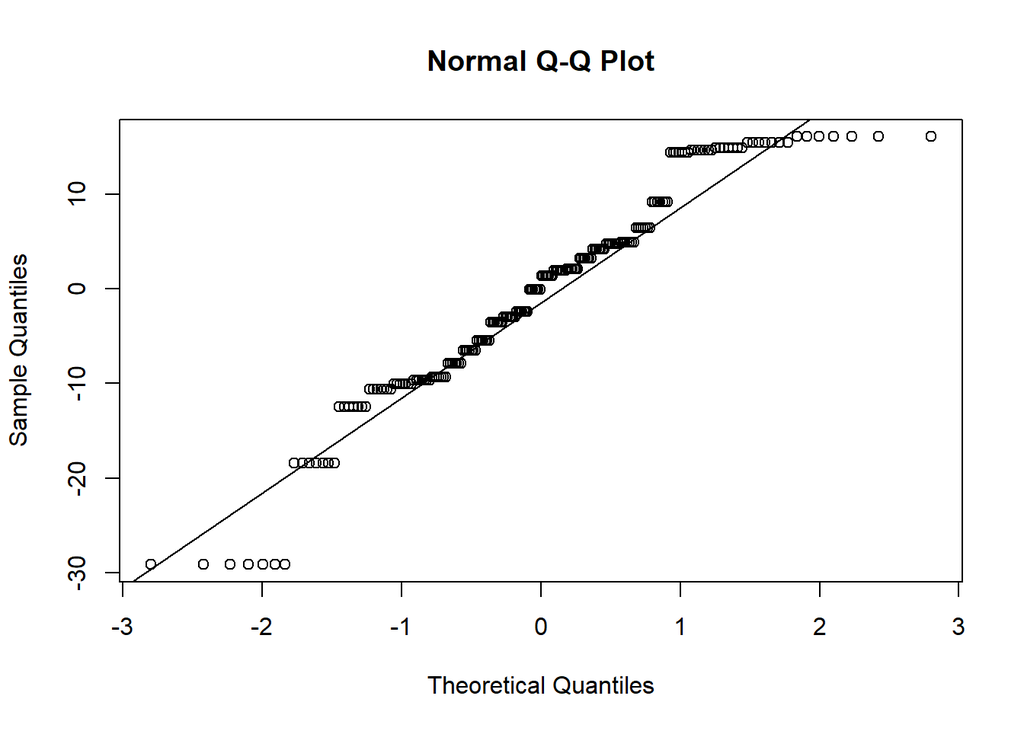

```r
# Q-Q plot
qqnorm(deviance_residuals_poisson)
#now qqline addition
qqline(deviance_residuals_poisson)
```

```r
#checks
define_qqline_check = 0
```

**(b) 4 pts - Using Cook’s Distance with threshold = 1, how many outliers are identified in “poisson_model”? Remove the outliers from the dataset and create poisson_model2 with the new dataset.**

```r
# Cook's Distance based outlier
cooks_distance <-cooks.distance(poisson_model)
check_cooks_distance = 0
#outlier defined
outliers <-which(cooks_distance >1)
outliers
```

```
##   1  23  24  28  29  51  52  56  57  79  80  84  85 107 108 112 113 135 136 140
##   1  23  24  28  29  51  52  56  57  79  80  84  85 107 108 112 113 135 136 140
## 141 163 164 168 169 191 192 196
## 141 163 164 168 169 191 192 196
```

```r
# Remove outliers from the dataset
bicycle_clean <-casedata[-outliers, ]
```

28 outliers were identified and removed. The new model, poisson_model2, was fitted to the cleaned dataset

```r
# Fit Poisson
poisson_model2 <-glm(Brooklyn.Bridge ~ High.Temp...F. +Low.Temp...F. +Precipitation +DayOfWeek,data =bicycle_clean, family=poisson)
#check model vals
#poisson_model2
summary(poisson_model2)
```

```
##
## Call:
## glm(formula = Brooklyn.Bridge ~ High.Temp...F. + Low.Temp...F. +
##     Precipitation + DayOfWeek, family = poisson, data = bicycle_clean)
##
## Coefficients:
##                      Estimate Std. Error z value Pr(>|z|)
## (Intercept)         5.9013499  0.0121128 487.201  < 2e-16 ***
## High.Temp...F.      0.0325196  0.0003305  98.406  < 2e-16 ***
## Low.Temp...F.       0.0021321  0.0003972   5.368 7.95e-08 ***
## Precipitation      -3.8035154  0.0465578 -81.694  < 2e-16 ***
## DayOfWeekMonday    -0.3824586  0.0077107 -49.601  < 2e-16 ***
## DayOfWeekSaturday  -0.3464100  0.0073812 -46.931  < 2e-16 ***
## DayOfWeekSunday    -0.3370210  0.0067643 -49.824  < 2e-16 ***
## DayOfWeekThursday  -0.1469290  0.0059516 -24.687  < 2e-16 ***
## DayOfWeekTuesday   -0.1519694  0.0068492 -22.188  < 2e-16 ***
## DayOfWeekWednesday  0.0478888  0.0058145   8.236  < 2e-16 ***
## ---
## Signif. codes:  0 '***' 0.001 '**' 0.01 '*' 0.05 '.' 0.1 ' ' 1
##
## (Dispersion parameter for poisson family taken to be 1)
##
##     Null deviance: 78498.5  on 167  degrees of freedom
## Residual deviance:  4851.6  on 158  degrees of freedom
## AIC: 6456
##
## Number of Fisher Scoring iterations: 4
```

**(c) 4 pts - Perform the deviance residual test to check the goodness-of-fit of poisson_model2. Is poisson_model2 a good fit? Discuss the appropriateness of using Cook’s Distance for poisson regression.**

```r
# Deviance poisson_model2
deviance_residuals_poisson2 <-residuals(poisson_model2,type ="deviance")
checl_deviance_residuals_mod2 = "Check if"
#return
summary(deviance_residuals_poisson2)
```

```
##     Min.  1st Qu.   Median     Mean  3rd Qu.     Max.
## -11.4258  -2.7418   0.3301  -0.2254   3.1434  11.9295
```

```r
# Goodness-of-fit test
goodness_of_fit <-sum(deviance_residuals_poisson2^2)/df.residual(poisson_model2)
#return
goodness_of_fit
```

```
## [1] 30.70662
```

The deviance residuals and goodness-of-fit test suggest that poisson_model2 has an improved fit over the original model, but since using Cook’s Distance for Poisson regression can sometimes be inappropriate (assumes the residuals are approximately normally distributed), this may not be true for count data.

**(d) 3 pts - Use the alternative method for outlier detection discussed in lecture 13 on the first Poisson model (“poisson_model”). How many outliers are identified? What assumption is made in this approach?**

```r
# Load necessary library
library(MASS) # For glm.nb function
# Fit Poisson regression model
poisson_model <- glm(Brooklyn.Bridge ~ High.Temp...F. + Low.Temp...F. + Precipitation + DayOfWeek, data = casedata, family = poisson)

# Calculate deviance residuals
dev_residuals <- residuals(poisson_model, type = "deviance")

# Identify outliers using the alternative method
# Deviance residuals are compared to the normal quantile with prob=0.99995
threshold <- qnorm(0.99995)
outliers_alt <- which(abs(dev_residuals) > threshold)
num_outliers_alt <- length(outliers_alt)

# Output the number of outliers identified
num_outliers_alt
```

```
## [1] 140
```

The alternative approach yielded a count of 140 outliers. The approach assumes that the deviance residuals follow a normal distribution under the null hypothesis of a good model fit. By comparing the residuals to the normal quantile at a high probability (0.99995), we can identify extreme outliers.